# Logistic Regression: Script Lecture 3

Michaela Kreyenfeld and Cristina Samper

Fall 2019

# 1 Finding the Optimal Model

With large N empirical observations, statistical modelling is used to reduce the complexity of multidimensional problems and find the ‘true’ isolated relation or effect (in the case of causal modelling) of exogenous factors (independent variables) on the phenomena that is being modelled (dependent variables). The ultimate goal of a statistician is to find a model that closely captures the distribution of the population observed, assuming the sample is representative of the population.

Finding the ‘right model’ requires many different steps and decisions along the way. On the one hand, it will be important to theorize on the nature of the outcome variable, and decide what type of model is known to best fit the type of variable we are observing. For example, the logistic regression is a good approach for dichotomous outcome variables. Then, further based on what is known from theory and other empirical studies and also depending on what is available in our data, we must further specify the variables we will use to model our data, and test our hypothesis. These are all necessary steps to find a good research design and we have been discussing this in the past lessons, this lesson will be a more technical one, as we will seek to understand how that chosen model is estimated.

To fully understand the algorithms used in programs like R to estimate the optimal model parameters would require that we understand some programing technicalities that are out of scope of this course, in this section we will get the intuition behind the model calculation process. We will get an idea of (1) how the program finds the model parameters and (2) how it decides and measures what the optimal ones are, given the data observed. Understanding this is important for us, because it will help us understand what the parameter significance means and how to compare model fitness between different specifications.

A commonly used method to estimate the coefficients of statistical models and specifically the logistic regression is called the maximum likelihood method. It is a method that instead of calculating the parameters directly by solving a system of equations, it instead looks at many different combinations of parameters and then chooses the set of parameters that will ‘best’ represent the observed data. It gives a recipe to find the parameters that ‘most likely give rise to the patterns in the population’ (Pampel 2000), by choosing the parameters that maximizing the ‘match’ between the model and the observations.

For some methods, like the linear regression, other more computationally efficient solutions might exist (ordinary least squares method). In the case of the logistic regression no analytical solution exists for most cases, so the maximum likelihood method is known to be the best approach. For a more formal definition of the maximum likelihood function you can refer to the appendix. Below we will not go into the formalities of this function but we will rather look at some basic examples of the maximum likelihood estimation method to get the intuition behind the calculations and this will help to understand the specific case of the logistic regression.

## 1.1 Maximum Likelihood Estimation Method different approach than OLS

In the case of OLS finding the optimal parameters is a task that can be done directly – or algebraically - by using the least squares method. Another way of confirming the parameters obtained by the least squares in the OLS are the optimal one would be to find the likelihood function (see appendix) and then maximize it, the least squares method can in fact be shown to be an equivalent to the maximum likelihood estimator of a continuous linear model with normally distributed errors- OLS. So for the case of OLS, the model with the parameters that minimize the squared differences between observed and predicted parameters, is in fact the model that most likely represents the pattern in the observed data.

For many statistical models the calculation of parameters is not as straightforward and analytic solutions might not exist, so the maximum likelihood estimation method can be a good solution to choose the best parameter specification for our model. A good way to understand how the likelihood function works and how it is maximized, is to look at it as a two layer problem: (1) On one layer there is a set of models (distributions) that are known to be a good fit to describe the trend in the data; and (2) in a second level (if it exists) it is possible to find one of those models defined by a set of parameters: $b_0,b_1,…,b_n$ that will maximize the likelihood of representing the data. Once the function set for a particular problem is defined, a statistical program can then look at different coefficient combinations. Using numerical methods for efficiency, such Newton – Raphson Method, it then finds the set of $b_0,b_1,…,b_n$ that give the highest likelihood of the sample observed to occur.

## 1.2 Maximum Likelihood Estimation: Intuitive example

To make the MLE more accessible and understand what it means to find the parameters that ‘most likely give rise to the patterns of observation in the sample data’ (Pampel 2000), let’s start with a simple example:

**Figure 1** Maximum Likelihood estimation example: Which proportion makes our drawn sample the most likely to represent our population?

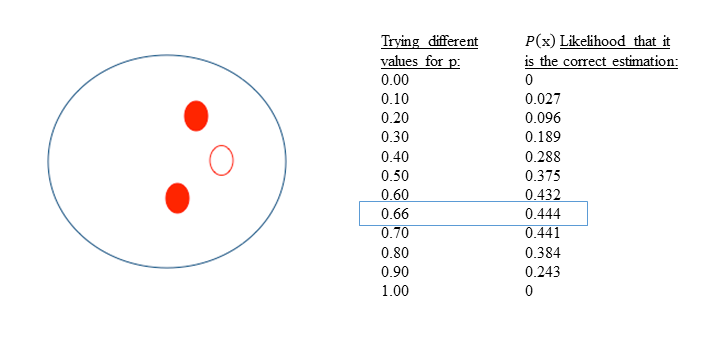

## 1.3 Maximum Likelihood Estimation: The Binomial distribution

A more formal example, yet still close to the intuitive example above, is finding the maximum likelihood estimation for n independent Bernoulli trials.

When we calculate the joint distribution, the likelihood function is a binomial distribution, which can be manually maximized, by looking at each of our observations. Set in the context of our example, if we assume that a person being conservative or not is independent from other persons’ ‘conservatism’ and that there is a real parameter $p$ in the population that determines the probability of being conservative and a probability $(1-p)$ of not being conservative, then in order to predict the best possible value of p from a drawn sample of the population, one can maximize the joint density function of the observed random trials (which in this case refers to people’s individual political preferences).

So we assume that there is some probability distribution function that determines the probability that a person is conservative given a sample of the population. The political position for a person i is then modeled by $f(x_i|P)$ as defined bellow:

$$f(x_i|P)=p^{x_i}(1-p)^{1-x_i}$$
(1)

where

$$x_i = \begin{cases}
1, & conservative \\
0, & non-conservative \\
\end{cases}$$
(2)

This equation works according to a given probability $p$ - which is what we want to estimate as the best parameter for the whole population. Note that the density function is defined for all the observations as either 1 or 0, meaning that it takes on value $p$ when the observation $x_i$ is conservative and the value $(1-p)$ if it is not conservative.

$$X_n = \sum_{i=1}^n x_i$$
(3)

$$P(X)=\prod_{1}^n f(x_i|P)=\prod_{1}^n p^{x_i}(1-p)^{1-x_i}=\frac{n!}{x!(n-x)!}[p^{x}(1-p)^{1-x}]$$
(4)

For $x=1,2,…n$

Then in order to calculate the maximum likelihood function we first have to find the likelihood function. Given the assumptions of independence above we know this is the same as calculating the joint probability distribution for all the observations (3), which after having a fixed $n$ for sample size (number of attempts in terms of Bernoulli trials - random experiments with two possible outcomes) and $x$ for number of success (number of times $x_i=1$) and some algebraic manipulation can be seen to converge into a binomial distribution (4). Where $P(x)$ is the joint probability distribution function for all observations in the sample, and $X$ is a random variable that follows a binomial distribution with parameters $n$ (Note that $X$ changes with each additional observation) and $p$ is the parameter we want to approximate in (1). Now because we know $p$ is a probability between 1 and 0, we can try different possible values and arrive to the most one that most likely represents the population (See Figure 1) .

Applied to our example, where $n=3$ and $x=2$ we can then manually (iteratively) try different estimations of the parameter that best represents the population according to when the likelihood function reaches its maximum. In Figure 1 we can see that as we had intuitively assessed the maximum likelihood estimation chooses the $p = .66$ that makes the probability of getting the observed outcome (Figure 1) as large as possible.

## 1.4 Log likelihood function: Maximum likelihood for the logistic distribution

In the example above, finding the maximum of the likelihood function by plugging in different values and then choosing the corresponding parameter was simple, because we were estimating a constant that we knew would fall between 0 and 1. But if we choose a more complex underlying distribution to describe our data, for example if we model the true parameters of the population according to the logistic distribution (5) (in place of the constant value p), the estimation process is much more complex and in many cases has no analytical solution. However, if you are interested in going deeper into the mathematical formalisms to get the maximum likelihood function in the ideal computational form, there is a good description of the procedure in Czepiel (2003). In the summary, in this article we show how the maximum likelihood function for the logistic regression is estimated by taking the first and second derivative of equation (6), which you might notice is very similar to the binomial distribution above, except with P defined as the logistic distribution with $b_0,b_1,… b_m$ , $m$ parameters to estimate (5). The final parameter estimation process is done using numerical estimation methods, based on the n observations in the sample.

$$P_i=\frac{1}{1+e^{-(b_0 + b_1 x_1 + ... + n_m x_m)}}$$
(5)

Parallel to the formula of the binomial regression the likelihood function in logistic regression is:

$$LF=\prod_{1}^{n} [P_i^{x_i}(1-P_i)^{1-x_i}]$$
(6)

Taking the natural logarithm on both sides of (6) and simplifying is equivalent to:

$$ln(LF)=\sum_{1}^{n} (x_i*ln(P_i)) + ((1-x_i)ln(1-P_i))$$
(7)

where $x_i$ refers to the observed value of the dichotomous dependent variable for case $i$ and takes on either values 1 or 0, and $P_i$ refers to the predicted probability for case $i$ considering a logistic distribution with parameters $b_0,b_1,… b_m$.

To find the first and second derivative of the likelihood function (6) and also for computational reasons- to avoid the multiplication of probabilities and having to work with very small numbers- the likelihood function is then turned into a logged likelihood function (7). After the transformation, the formally multiplied terms are now in summation form, making it an easier equation to work with, and no information is lost given that the log is a monotonously increasing function. Under this transformation the values that before ranged from 0 to 1 in the $LF$ function, now go from negative infinity to 0, well the natural log of 0 is undefined, but as the probability gets closer to 0 the natural log becomes increasingly negative, while the closer the likelihood is to 1 then the closer the $ln(LF)$ is closer to 0. So the maximum likelihood function is given for the coefficients $b_0,b_1,… b_m$ such that the value obtained from (7) is closest to 0.

In the class you can find two examples where we estimated the coefficients in the case of a null model, and one with a bivariate model by plugging in different combinations of coefficients in (5) and (7). For a good recap on the algorithm to do this exercise, refer to Pampel (2000) and for more information on an efficient computing procedure please refer again to Czepiel (2003).

# 2 Understanding R output: Model Fit and Significance Test

The log likelihood function has little meaning on its own because it depends on three things: the sample size, the number of parameters included in the model and how well it fits the data, however if we compare the log likelihood of a model with that of the null model (where all of the $x_i$ equal 0) or another nested model, as a baseline, we can get some information on the model fit. Let’s see a simple example:

```r
#Insert data
DEP  <-   c(1,1,1,0,1,0,0,0)
SEX  <-   c(0,0,0,0,1,1,1,1)
ZERO <-   c(0,0,0,0,0,0,0,0)
DATA02 = data.frame(DEP,SEX,ZERO)

OUTPUT02 <- glm(DEP~ SEX,data=DATA02, family=binomial())
summary(OUTPUT02)
```

```
##
## Call:
## glm(formula = DEP ~ SEX, family = binomial(), data = DATA02)
##
## Deviance Residuals:
##     Min       1Q   Median       3Q      Max
## -1.6651  -0.7585   0.0000   0.7585   1.6651
##
## Coefficients:
##             Estimate Std. Error z value Pr(>|z|)
## (Intercept)    1.099      1.155   0.951    0.341
## SEX           -2.197      1.633  -1.346    0.178
##
## (Dispersion parameter for binomial family taken to be 1)
##
##     Null deviance: 11.0904  on 7  degrees of freedom
## Residual deviance:  8.9974  on 6  degrees of freedom
## AIC: 12.997
##
## Number of Fisher Scoring iterations: 4
```

## 2.1 Deviance residuals

In the top of the summary table we first get information on the deviance residuals. These are residuals calculated with the likelihood ratio chi-squared statistic. The calculations are not as simple as the case of the linear model where you just calculate the difference between the observed and fitted values because each observation has a different variance. For more information on the equation used to calculate the deviance residuals you can look at Rodiguez (2019). The deviance residuals can already give us a sense of how the model fits as observations with a deviance residual greater than two may indicate lack of fit.

In the bottom of the summary table we get more information on the residual deviance. These values are calculated according to the maximum log likelihood estimation (mle) of different model specifications:

- The *Saturated model* a model in which each observation has its own parameter, so given a sample size n, this would be a model with n parameters.
- The *Null model* a model with 1 parameter (the intercept) that represents all data points.
- The *Proposed model* the model calculated in the specification, it explains the data points with p parameters and the intecept, so it has p+1 parameters.

Then considering these 3 possible models the Null deviance and the Residual deviance are calculated by:

- **Null deviance** = $2[mle(Saturated\_model)-mle(Null\_model)]$ on degrees of freedom $df=df(Saturated\_model)-df(Null\_model)$
- **Residual deviance** = $2[mle(Saturated\_model)-mle(Proposed\_model)]$ on degrees of freedom $df=df(Saturated\_model)-df(Proposed\_model)$

The lower the deviance the better the model.

## 2.2 AIC: Akaike Information Criterion

At the bottom of the summary table we can also find the Akaike Information Criterion AIC value. AIC is founded in information theory, it is a combined measure of fit and complexity. While considering goodness of fit, it also penalizes a model with too many parameters.This discourages overfitting (using two variables that are highly correlated). If $k$ is the number of estimated parameters and MLE be the maximum value of the likelihood estimate for the model. Then the AIC value of the model is

$$AIC= 2k-2ln(MLE)$$

The closer the value is to 0, the better the model. The value alone is difficult to interpret, but you can compare two models based on this number (no need for nesting).

## 2.3 Log likelihood ratio test: G test

Another method to asses fit or compare two models is the likelihood ratio test. The greater the difference between the maximum log likelihood estimation (mle) of the baseline (null) model and the mle of the model with covariates (proposed model), the better the selected coefficients for estimation. When we estimate the coefficients of our model with R, similarly to what we know in OLS, we are given the coefficients coupled with measurements of significance. As we saw in the examples above in order to arrive at the maximum likelihood estimation a numerical algorithm iterates through different options. The number of iterations it took the algorithm to reach the mle solution is mentioned in the bottom of the model as the *Fisher Scoring iterations*. In order to find the mle value, the log likelihood obtained in the 4th iteration of our example, we can access it from the attributes of the model:

```r
logLik(OUTPUT02)
```

```
## 'log Lik.' -4.498681 (df=2)
```

Now we can calculate the base (null) model, a model without independent covariates and its maximum log likelihood estimation.

```r
OUTPUT01 <- glm(DEP ~ 1, data=DATA02, family=binomial())
logLik(OUTPUT01)
```

```
## 'log Lik.' -5.545177 (df=1)
```

To compare these two values, and test whether inserting new covariates results in a better fitting model, we can now use the log likelihood ratio test, also called the G test-statistic (8).

$$G=-2[MLE_0-MLE_1]$$
(8)

```r
#LL-Ratio-Test
LL0 <- logLik(OUTPUT01)
LL1 <- logLik(OUTPUT02)
DATA03 = data.frame(LL0,LL1)
LL_DIFF <- -2*(DATA03$LL0-DATA03$LL1)
LL_DIFF
```

```
## [1] 2.092993
```

```r
qchisq(.95, df=1)
```

```
## [1] 3.841459
```

Let’s interpret the example above. Similar to the F test used to compare different statistical models and test the null hypothesis that $b_1=b_2=⋯=b_m=0$, we also test the differences between the parameters. If the calculated G test from the data is greater than the critical value of the $chi^2$ distribution with $i$ degrees of freedom, then we reject the null hypothesis and affirm that the parameters are significantly different from each other and from 0. When we take the difference – or ratio - between the baseline mle (`LLO`) and the mle of the model with covariates (`LL1`) and multiply the difference by -2, the resultant value `2.09` follows a chi-squared distribution. If we then compare this value with the chi^2 at the .05 level, with 1 degree of freedom (`OUTPUT2` has one covariate more than `OUTPUT1`), which is 3.84 and test reaches the critical value, then the second model is considered a better fit. In this case 2.09 < 3.84 so we cannot say the model with the extra covariate (`OUTPUT2`) is improving the fit of the model significantly.

An alternative to calculating the LR test manually, different packages in R have a function that can calculate the test for us. One is `lrtest(model1, model2)` from the package `lmtest`, in this case `model1` has to be nested in `model2`.

```r
require(lmtest)
lrtest(OUTPUT01, OUTPUT02)
```

```
## Likelihood ratio test
##
## Model 1: DEP ~ 1
## Model 2: DEP ~ SEX
##   #Df  LogLik Df Chisq Pr(>Chisq)
## 1   1 -5.5452
## 2   2 -4.4987  1 2.093      0.148
```

Test output gives us the same information as we calculated above manually. The final value `Pr(>Chisq)= 0.148` indicates that the G test did not pass the critical value.

## 2.4 Pseudo R^2

Different to the R square measure for the OLS, the measure of fit for the logistic model is more controversial. One of the measures used for this is Pseudo R squared (9). The larger the difference is between $MLE_1$ and $MLE_0$, the larger the pseudo R squared. The idea is that if the more complex model fits the data much better than the other, then the measure will be closer to one. In practice however, it is common that the values range from 0.1-0.2 so the magnitude of the r square is different from what is common for OLS-regressions.

$$Pseudo R^2=1-\frac{MLE_1}{MLE_0}$$
(9)

```r
PSEUDO_R2 <- 1-(DATA03$LL1/DATA03$LL0)
PSEUDO_R2
```

```
## [1] 0.1887219
```

Given the information we obtain in the model summary above the Pseudo R^2 can also be calculated from the reported Null deviance and Residual deviance.

$$Pseudo R^2=1-\frac{Residual\_deviance}{Null\_deviance}$$

```r
1-(8.9974/11.0904)
```

```
## [1] 0.1887218
```

## 2.5 Parameter Significance

The significance of parameters is interpreted similarly as it is done in OLS.

```r
# coefficients
summary(OUTPUT02)$coefficients
```

```
##              Estimate Std. Error   z value  Pr(>|z|)
## (Intercept)  1.098612   1.154700  0.951427 0.3413877
## SEX         -2.197225   1.632992 -1.345521 0.1784571
```

```r
# logged odds
exp(summary(OUTPUT02)$coefficients)
```

```
##              Estimate Std. Error  z value Pr(>|z|)
## (Intercept) 3.0000000   3.173070 2.589402 1.406899
## SEX         0.1111111   5.119167 0.260404 1.195372
```

The level of significance obtained when looking at the results in terms of the $β$ coefficients or logged odds is the same regardless of the form. The standard errors and the confidence intervals do change however, because these measures show the variation with respect to the parameter observed and it is given for the specific scale we are observing. The test statistic $z$ is normally distributed.

$$z=\frac{β}{Se(β)}$$
(10)

$$Confidence\_intervals(95\%)=β+1.96*Se(β)$$
(11)

Please note: The strength of the effect and the significance of the parameter are different concepts. The OR measures the strength of the effect. It is common in empirical research to focus interpretation of the OR that are significant at least on the 5% level. However, this practice is highly controversial (Bernardi et al 2016).

# 3 Appendix: Formal mathematical definition of the maximum likelihood estimator

The maximum likelihood principle says that given a data set, the parameters of the chosen model are found in such a way that the data are more ‘likely’. Or in other words, according to the available sample, for all possible combinations of parameters in a multivariate model, the maximum likelihood estimator gives the parameters for which the probability is highest.

In Figure 4 we can see an illustration of the difference between the probability and the likelihood. A probability comes from assuming a reality model of the population; it is used to describe possible outcomes given a fixed value of the parameters of the population. The probability gives the odds of an event, given any parameters. The likelihood on the other hand, is only given in relation to an available set of data; it is a function of the parameters of the statistical model, and gives the odds of parameters given data.

Figure 4: Probability vs. Likelihood

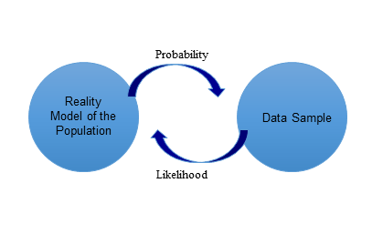

Regardless of the distribution chosen to characterize the common probability distribution of the model of the individual observations in the random sample, if you have a random sample $X_1,X_2,…,X_n$ with common probability density function $f(x;θ)$, where θ is a vector of m parameters $b_0,b_1,…,b_m$, the likelihood function and it’s $log$ are given by:

$$L(θ)=\prod_{i=1}^nf(x_i;θ)$$

$$l(θ)=log L(θ)=\sum_{i=1}^nf(x_i;θ)$$

Mathematically, the log is more convenient to work with and no information is lost because the log is a 1-1 function. The maximum likelihood function is then such that the values in $θ$ would maximize the probability $L(θ)$ of obtaining the particularly observed sample $x_1,x_2…,x_n$, and since $L(θ)$ and its logarithm $l(θ)$ are maximized for the same values of θ, either can be used. Then there is no guarantee that the mlle exists or whether it is unique; but if it does exist, then the estimate of $θ$ that maximizes $L(θ)$ would be the $θ$ that solves the vector equation $\frac{∂}{∂θ}l(θ)=0$, of first partial derivatives, where $0$ is a vector of length $m$. But as mentioned above, there are many cases where there is no analytical solution to find $θ$, so numerical approximation methods, are used by statistical programs to approximate it.

For more details on different conditions – such as regularity- that must be satisfied for the mlle to exist and also for further characterizations $θ$ you can look at more advanced books for statistics, such as Ross (2014, Chp. 7).

# 4 References

Czepiel, S. A. (2002). *Maximum likelihood estimation of logistic regression models: theory and implementation*. Available at czep. net/stat/mlelr. pdf.

Pampel, F. C. (2000). *Logistic regression: A primer* (Vol. 132). Sage.

Ross, S. M. (2014). *Introduction to probability and statistics for engineers and scientists*. Academic Press.

Rodriguez, G. (2019) *Generalized Linear Models. 3.8 Regression Diagnostics for Binary Data*. Retrieved from: https://data.princeton.edu/wws509/notes/c3s8

# 5 Acknowledgment

For many helpful comments and the course material, I thank Michaela Kreyenfeld. For editing, I thank Lena Klein. All remaining errors are my own.